# Crime Analysis

Purbasha Chatterjee

May 1, 2018

Data Source: https://catalog.data.gov/dataset/crimes-2001-to-present-398a4

Data Size: 1 GB

Data Format: CSV File

The data consist of crime reports in the city of Chicago from year 2001 to present

Analyzing the crime pattern across different areas

Objective: Analyze the pattern so that required strategies could be implemented and future risks could be mitigated.

Summary of the crime data in the city of Chicago from 2001-present

```r
library(ggplot2)
library(plyr)
library(dplyr)
crime <- read.csv("Crimes_-_2001_to_present.csv",header=TRUE)
attach(crime)
library(car)
summary(crime)
```

```
##        ID             Case.Number                          Date
##  Min.   :     634   HJ590004:      6   01/01/2001 12:00:00 AM:    189
##  1st Qu.: 2745936   HZ140230:      6   01/01/2003 12:01:00 AM:    179
##  Median : 7637146   HP296582:      5   01/01/2003 12:00:00 AM:    174
##  Mean   : 6478257   HS256531:      5   01/01/2008 12:01:00 AM:    165
##  3rd Qu.: 9446643   HJ104730:      4   01/01/2012 12:01:00 AM:    160
##  Max.   :11299089   HJ756295:      4   01/01/2002 12:01:00 AM:    150
##                     (Other) :4585928   (Other)               :4584941
##                   Block              IUCR
##  001XX N STATE ST    :   9156   0820   : 404960
##  100XX W OHARE ST    :   8275   0460   : 359575
##  008XX N MICHIGAN AVE:   6101   0486   : 334477
##  076XX S CICERO AVE  :   5985   0810   : 242280
##  0000X N STATE ST    :   5474   1320   : 241199
##  0000X W TERMINAL ST :   4335   1310   : 237542
##  (Other)             :4546632   (Other):2765925
##           Primary.Type                      Description
##  THEFT          : 982869   SIMPLE                 : 561290
##  BATTERY        : 839421   $500 AND UNDER         : 404951
##  CRIMINAL DAMAGE: 511074   DOMESTIC BATTERY SIMPLE: 334477
##  NARCOTICS      : 461831   TO VEHICLE             : 249851
##  ASSAULT        : 286626   OVER $500              : 242271
##  OTHER OFFENSE  : 284451   TO PROPERTY            : 237542
##  (Other)        :1219686   (Other)                :2555576
##                      Location.Description   Arrest         Domestic
##  STREET                        :1194785   false:3336217   false:3963679
##  RESIDENCE                     : 783385   true :1249741   true : 622279
##  APARTMENT                     : 478775
##  SIDEWALK                      : 436900
##  OTHER                         : 177022
##  PARKING LOT/GARAGE(NON.RESID.): 134756
##  (Other)                       :1380335
##       Beat         District          Ward        Community.Area
##  Min.   : 111   Min.   : 1.00   Min.   : 1.0     Min.   : 0.0
##  1st Qu.: 622   1st Qu.: 6.00   1st Qu.:10.0     1st Qu.:23.0
##  Median :1111   Median :10.00   Median :23.0     Median :32.0
##  Mean   :1188   Mean   :11.31   Mean   :22.7     Mean   :37.5
##  3rd Qu.:1731   3rd Qu.:17.00   3rd Qu.:34.0     3rd Qu.:57.0
##  Max.   :2535   Max.   :31.00   Max.   :50.0     Max.   :77.0
##                 NA's   :18      NA's   :614688   NA's   :615342
```

[output cut: 9 more lines]

```
##  02/10/2018 03:50:01 PM:2793048   Min.   :36.62    Min.   :-91.69
##  02/28/2018 03:56:25 PM: 776163   1st Qu.:41.77    1st Qu.:-87.71
##  08/17/2015 03:03:40 PM: 536780   Median :41.86    Median :-87.67
##  02/04/2016 06:33:39 AM: 349352   Mean   :41.84    Mean   :-87.67
##  04/28/2018 03:54:33 PM:  72209   3rd Qu.:41.91    3rd Qu.:-87.63
##  02/14/2017 03:49:42 PM:  18203   Max.   :42.02    Max.   :-87.52
##  (Other)               :  40203   NA's   :128910   NA's   :128910
##                           Location
##                               : 128910
##  (41.754592961, -87.741528537):   6116
##  (41.976290414, -87.905227221):   6101
##  (41.883500187, -87.627876698):   4833
##  (41.897895128, -87.624096605):   3063
##  (41.896888586, -87.628203192):   2303
##  (Other)                      :4434632
```

Analyzing the patterns of domestic and non-domestic crime situations across different district.

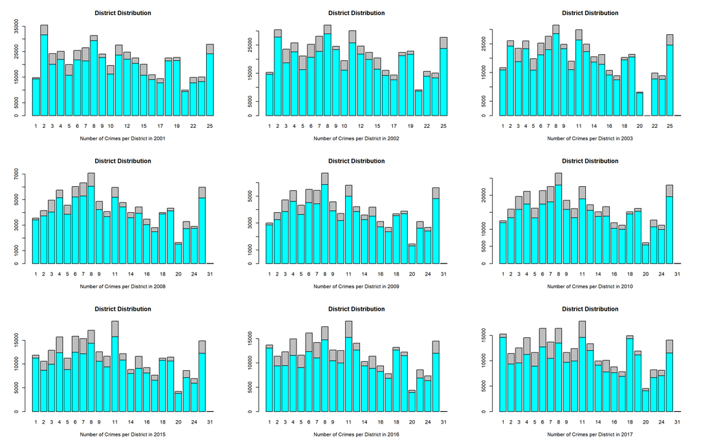

```r
years <- unique(crime$Year)
for (year in years){
  assign(paste("year_", year, sep = ""),crime[ which(crime$Year==year),])
}

count_dom_2001 <- table(year_2001$Domestic, year_2001$District)
count_dom_2002 <- table(year_2002$Domestic, year_2002$District)
count_dom_2003 <- table(year_2003$Domestic, year_2003$District)
count_dom_2004 <- table(year_2004$Domestic, year_2004$District)
count_dom_2005 <- table(year_2005$Domestic, year_2005$District)
count_dom_2006 <- table(year_2006$Domestic, year_2006$District)
count_dom_2007 <- table(year_2007$Domestic, year_2007$District)
count_dom_2008 <- table(year_2008$Domestic, year_2008$District)
count_dom_2009 <- table(year_2009$Domestic, year_2009$District)
count_dom_2010 <- table(year_2010$Domestic, year_2010$District)
count_dom_2011 <- table(year_2011$Domestic, year_2011$District)
count_dom_2012 <- table(year_2012$Domestic, year_2012$District)
count_dom_2013 <- table(year_2013$Domestic, year_2013$District)
count_dom_2014 <- table(year_2014$Domestic, year_2014$District)
count_dom_2015 <- table(year_2015$Domestic, year_2015$District)
count_dom_2016 <- table(year_2016$Domestic, year_2016$District)
count_dom_2017 <- table(year_2017$Domestic, year_2017$District)
count_dom_2018 <- table(year_2018$Domestic, year_2018$District)


par(mfrow=c(3, 3))
with(year_2001, barplot(count_dom_2001, main="District Distribution",col = c("cyan", "grey"),
                        xlab="Number of Crimes per District in 2001"))


with(year_2002, barplot(count_dom_2002, main="District Distribution",col = c("cyan", "grey"),
                        xlab="Number of Crimes per District in 2002"))


with(year_2003, barplot(count_dom_2003, main="District Distribution",col = c("cyan", "grey"),
                        xlab="Number of Crimes per District in 2003"))

with(year_2008, barplot(count_dom_2008, main="District Distribution",col = c("cyan", "grey"),
                        xlab="Number of Crimes per District in 2008"))
with(year_2009, barplot(count_dom_2009, main="District Distribution",col = c("cyan", "grey"),
                        xlab="Number of Crimes per District in 2009"))
with(year_2010, barplot(count_dom_2010, main="District Distribution",col = c("cyan", "grey"),
                        xlab="Number of Crimes per District in 2010"))

with(year_2015, barplot(count_dom_2015, main="District Distribution",col = c("cyan", "grey"),
                        xlab="Number of Crimes per District in 2015"))


with(year_2016, barplot(count_dom_2016, main="District Distribution",col = c("cyan", "grey"),
                        xlab="Number of Crimes per District in 2016"))

with(year_2017, barplot(count_dom_2017, main="District Distribution",col = c("cyan", "grey"),
                        xlab="Number of Crimes per District in 2017"))
```

Analyzing the Percentage of crime rate across the areas in the year 2018

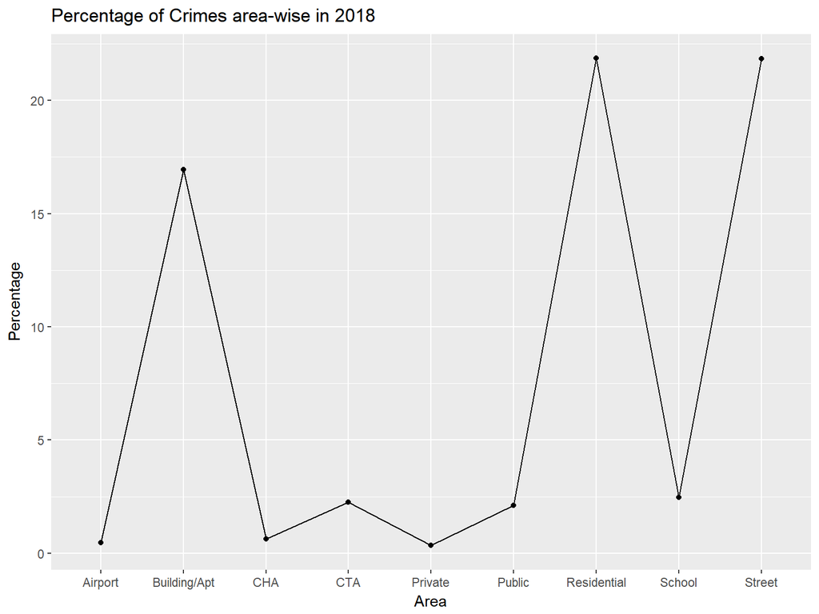

```r
library(stringr)

## For Year 2018
count_arr <- table(year_2018$Location.Description, year_2018$Arrest)
count_arr <- as.data.frame(count_arr)
airport<-subset(count_arr,str_detect(count_arr$Var1, "AIRPORT")==TRUE)
street<-subset(count_arr,str_detect(count_arr$Var1, "STREET")==TRUE)
residential <-subset(count_arr,str_detect(count_arr$Var1, "RESIDE")==TRUE)
public <-subset(count_arr,str_detect(count_arr$Var1, "PUBLIC")==TRUE)
school <-subset(count_arr,str_detect(count_arr$Var1, "SCHOOL")==TRUE)
private <-subset(count_arr,str_detect(count_arr$Var1, "PRIVATE")==TRUE)
building <- subset(count_arr,str_detect(count_arr$Var1, "BUILDING")==TRUE)
apartment <- subset(count_arr,str_detect(count_arr$Var1, "APARTMENT")==TRUE)
CTA <- subset(count_arr,str_detect(count_arr$Var1, "CTA")==TRUE)
CHA <- subset(count_arr,str_detect(count_arr$Var1, "CHA")==TRUE)

air_sum <- sum(airport$Freq)/sum(count_arr$Freq)
street_sum <- sum(street$Freq)/sum(count_arr$Freq)
resid <- sum(residential$Freq)/sum(count_arr$Freq)
publ <- sum(public$Freq)/sum(count_arr$Freq)
sch <- sum(school$Freq)/sum(count_arr$Freq)
priv <- sum(private$Freq)/sum(count_arr$Freq)
build <- (sum(building$Freq) +sum(apartment$Freq))/sum(count_arr$Freq)
cta <- sum(CTA$Freq)/sum(count_arr$Freq)
cha <- sum(CHA$Freq)/sum(count_arr$Freq)

area_name = c("Airport","Street", "Residential","School","Public", "Private","Building/Apt","CTA", "CHA")
area_freq = c(air_sum, street_sum, resid, sch, publ,priv,build,cta, cha)

df.crime_area = data.frame(x=area_name, y=area_freq)
ggplot(data=df.crime_area, aes(x,y*100, group=1)) +
  geom_point() + geom_line() + xlab("Area") + ylab("Percentage") +
  ggtitle("Percentage of Crimes area-wise in 2018")
```

Oservation: Resedential Area suffers the maximum criminal situations.

Let’s analyze the Percentage of crime rate across the areas in the year 2017

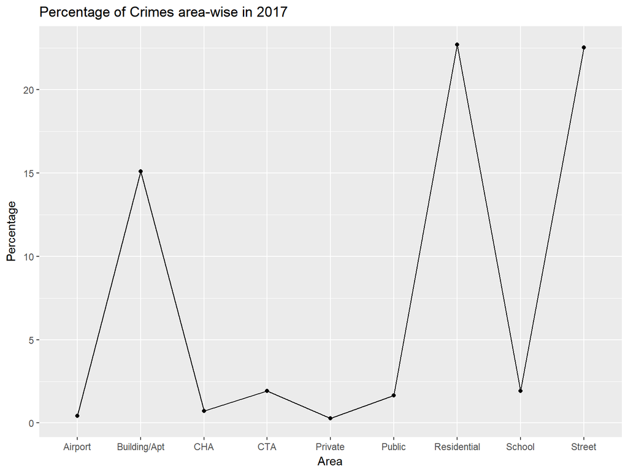

```r
## For year 2017
count_arr1 <- table(year_2017$Location.Description, year_2017$Arrest)
count_arr1 <- as.data.frame(count_arr1)
airport1<-subset(count_arr1,str_detect(count_arr1$Var1, "AIRPORT")==TRUE)
street1<-subset(count_arr1,str_detect(count_arr1$Var1, "STREET")==TRUE)
residential1 <-subset(count_arr1,str_detect(count_arr1$Var1, "RESIDE")==TRUE)
public1 <-subset(count_arr1,str_detect(count_arr1$Var1, "PUBLIC")==TRUE)
school1 <-subset(count_arr1,str_detect(count_arr1$Var1, "SCHOOL")==TRUE)
private1 <-subset(count_arr1,str_detect(count_arr1$Var1, "PRIVATE")==TRUE)
building1 <- subset(count_arr1,str_detect(count_arr1$Var1, "BUILDING")==TRUE)
apartment1 <- subset(count_arr1,str_detect(count_arr1$Var1, "APARTMENT")==TRUE)
CTA1 <- subset(count_arr1,str_detect(count_arr1$Var1, "CTA")==TRUE)
CHA1 <- subset(count_arr1,str_detect(count_arr1$Var1, "CHA")==TRUE)

air_sum1 <- sum(airport1$Freq)/sum(count_arr1$Freq)
street_sum1 <- sum(street1$Freq)/sum(count_arr1$Freq)
resid1 <- sum(residential1$Freq)/sum(count_arr1$Freq)
publ1 <- sum(public1$Freq)/sum(count_arr1$Freq)
sch1 <- sum(school1$Freq)/sum(count_arr1$Freq)
priv1 <- sum(private1$Freq)/sum(count_arr1$Freq)
build1 <- (sum(building1$Freq) +sum(apartment1$Freq))/sum(count_arr1$Freq)
cta1 <- sum(CTA1$Freq)/sum(count_arr1$Freq)
cha1 <- sum(CHA1$Freq)/sum(count_arr1$Freq)

#area_name = c("Airport", "Residential","School","Public", "Private","Building/Apt","CTA", "CHA")
area_freq1 = c(air_sum1, street_sum1, resid1, sch1, publ1,priv1,build1,cta1, cha1)

df.crime_area_17 = data.frame(x=area_name, y=area_freq1)
ggplot(data=df.crime_area_17, aes(x,y*100, group=1)) +
  geom_point() + geom_line() + xlab("Area") + ylab("Percentage") +
  ggtitle("Percentage of Crimes area-wise in 2017")
```

The trend remains the same in year 2017 for resedential area Let’s analyze the heat-map of resedential area against different types of crime.

```r
df <- crime %>%
  filter(str_detect(Location.Description, "RESIDE")==TRUE) %>%
  group_by(Primary.Type, Year) %>%
  summarise(n = n())
```

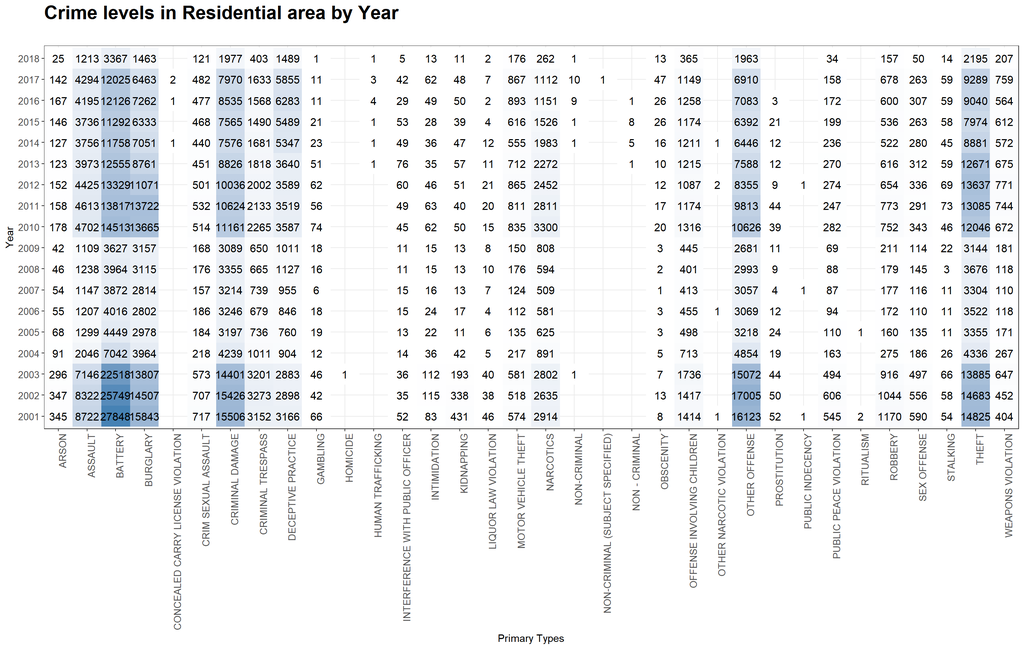

```r
resid_heatmap <- ggplot(df, aes(y=factor(Year),x=Primary.Type, fill=n)) +
  geom_tile(aes(fill=n)) +
  geom_text(aes(label=n), size=4, color="black") +
  scale_x_discrete("Primary Types", expand = c(0,-1)) +
  scale_y_discrete("Year") +
  scale_fill_gradient("Frequency", low = "white", high = "steelblue") +
  ylab("Year") +
  xlab("Primary Types") +
  theme_bw() +
  theme(axis.text.x = element_text(angle = 90, hjust = 1)) +
  theme(axis.text=element_text(size=10)) +
  theme(legend.position="none") +
  ggtitle("Crime levels in Residential area by Year\n") +
  theme(plot.title = element_text(face="bold", size="20"))
resid_heatmap
```

Battery is the most observed crime type followed by Theft type Similarly, analyzing the building and apartment area

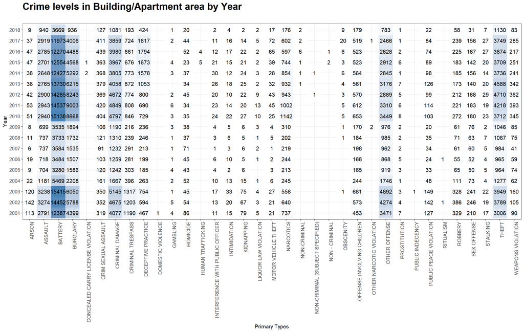

```r
df2 <- crime %>%
  filter(str_detect(Location.Description, "BUILDING")==TRUE) %>%
  group_by(Primary.Type, Year) %>%
  summarise(n = n())

df3 <- crime %>%
  filter(str_detect(Location.Description, "APARTMENT")==TRUE) %>%
  group_by(Primary.Type, Year) %>%
  summarise(n = n())
for (i in 1:ncol(df3)){
  if(df2$Primary.Type[i]==df3$Primary.Type[i] && df2$Year[i]==df3$Year[i]){
    tot <- df2$n[i]+df3$n[i]
    df3$n[i] <- tot
  }
}
  ggplot(df3, aes(y=factor(Year),x=Primary.Type, fill=n)) +
  geom_tile(aes(fill=n)) +
  geom_text(aes(label=n), size=4, color="black") +
  scale_x_discrete("Primary Types", expand = c(0,-1)) +
  scale_y_discrete("Year") +
  scale_fill_gradient("Frequency", low = "white", high = "steelblue") +
  ylab("Year") +
  xlab("Primary Types") +
  theme_bw() +
  theme(axis.text.x = element_text(angle = 90, hjust = 1)) +
  theme(axis.text=element_text(size=10)) +
  theme(legend.position="none") +
  ggtitle("Crime levels in Building/Apartment area by Year\n") +
  theme(plot.title = element_text(face="bold", size="20"))
```

Developing a model

```r
  library(caret)
residential_sub <- subset(crime,str_detect(Location.Description, "RESIDE")==TRUE)
#residential_sub_prim <- table(residential_sub$Primary.Type, residential_sub$Year)
#residential_sub_prim <- as.data.frame(residential_sub_prim)

for(i in 1:ncol(residential_sub)){
  if((str_detect(residential_sub$Primary.Type[i], "BATTERY")==TRUE)
     ||(str_detect(residential_sub$Primary.Type[i], "THEFT")==TRUE)){
    residential_sub$Type[i] <- 0
  }
 else{
    residential_sub$Type[i] <- 1
  }
}

residential_sub$District[is.na(residential_sub$District)] <- 0
residential_sub$Ward[is.na(residential_sub$Ward)] <- 0
residential_sub$Community.Area[is.na(residential_sub$Community.Area)] <- 0

set.seed(3035)
intrain <- createDataPartition(y = residential_sub$Type, p= 0.7, list = FALSE)
training <- residential_sub[intrain,]
testing <- residential_sub[-intrain,]
#anyNA(residential_sub$Year)
trctrl <- trainControl(method = "cv", number = 10)
set.seed(3235)
```